# Tracing carvers on the rock

Code to reproduce the results

Author

Affiliation

[Julián Moyano Di Carlo](https://www.researchgate.net/profile/Julian-Moyano-Di-Carlo?ev=hdr_xprf)

[Department of Historical Studies (GU)](https://www.gu.se/en/historical-studies)

Published

August 6, 2026

**Note**

This notebook was executed with R v4.5.3

## Introduction

This document provides the supplemental Information accompanying Chapter 7 of the book “[Masters of Water and Stone. Exploring the Role of Rock Art Carvers in Nordic Bronze Age Societies](https://www.oxbowbooks.com/9798888573044/masters-of-water-and-stone/)”. All data required to reproduce the main analyses is available in the Zenodo repository that includes this markdown document.

For more information about the research questions and rationale behind these analyses, as well as the interpretation of the results, please read the book.

## Directory and libraries

The following code loads and install, if necessary, all packages used in the script on the date they were last used to ensure reproducibility.

- `here` and `groundhog` are used for reproducibility

**Tip**

The function `groundhog.library` must be executed twice: one time to install packages, and another time to load them. To load the packages in the the current date run `lapply(pkgs, library, character.only=TRUE)` instead.

- `readr` and `sf` are used to read .csv and .shp files
- `dplyr`, `forcats`, `glue`, `purrr`, `tibble`, and `tidyr` are use for data cleaning and exploratory data analysis - `ggplot2`, `ggpubr`, `ggrepel`, and `scales` are used for plotting
- `geomoporh` and `momocs` are used for morphometrics
- `dispRity` is used for disparity analysis
- `knitr` and `rmarkdown` are used to produce the notebook

```r
# Clean environment
rm(list=ls())

# Required packages
pkgs <- c("dispRity", "dplyr", "forcats", "ggplot2", "ggpubr", "ggrepel", "glue", "here", "knitr", "Momocs", "purrr", "readr", "rmarkdown", "scales", "sf", "tibble", "tidyr", "geomorph")

# Load packages on date of use (and install if necessary)
require("groundhog")
groundhog.library(pkgs, "2025-10-1")

# Setting directory
here::i_am("scripts/Tracing-the-carvers.qmd")
```

## Datasets

The data used in this script comes from two shapefiles. `AspebergetFigures.shp` is a multipolygon feature containing all figures at Aspeberget, with additional information (size, depth, chronology, etc.). `BohuslanShips.shp` is a multipolygon feature containing 746 ship figures, with additional information (size, length, chronology, etc.).

```r
# Import shape file with figures information
AspebergetFigures <- st_drop_geometry(st_read(here("data/shp/AspebergetFigures.shp")))
# Import metadata for Bohuslan ships
BohuslanShips <- st_drop_geometry(st_read(here("data/shp/BohuslanShips.shp")))
```

## Partial figures analysis

This section analyzes the rate of partial depiction of figures at Aspeberget and compares it across phases, panels, and figure types. A partial figure is defined as one that lacks some of its basic attributes. For example, a human figure missing one leg or a ship missing the prow or a stern.

### Chi-square test

Chi-square analysis was performed to evaluate the statistical significance of differences between phases, panels, and types of figures.

```r
# Create contingency table
tab_chisq_type <- table(AspebergetFigures$Type, AspebergetFigures$Depiction)
tab_chisq_raa <- table(AspebergetFigures$RAAnr, AspebergetFigures$Depiction)
tab_chisq_phase <- table(AspebergetFigures$Phase, AspebergetFigures$Depiction)

# Filter relevant cases
tab_chisq_type <- tab_chisq_type[c("Animal", "Ship", "Circle", "Human", "Foot/Shoe sole"), ]
tab_chisq_raa <- tab_chisq_raa[c("Tanum 12:1", "Tanum 18:1", "Tanum 25:1", "Tanum 28:1", "Tanum 120:1"), ]
tab_chisq_phase <- tab_chisq_phase[c("1", "2", "3", "4", "5"), ]

# Chi-squared test
chisq_result_type <- chisq.test(tab_chisq_type)
chisq_result_raa <- chisq.test(tab_chisq_raa)
chisq_result_phase <- chisq.test(tab_chisq_phase)

# Extract and format p-value for plotting
p_value_type <- chisq_result_type$p.value
p_value_raa <- chisq_result_raa$p.value
p_value_phase <- chisq_result_phase$p.value

p_label_type <- glue("Chi-sq, p {scales::pvalue(p_value_type, accuracy = 0.001)}")
p_label_raa <- glue("Chi-sq, p = {scales::pvalue(p_value_raa, accuracy = 0.001)}")
p_label_phase <- glue("Chi-sq, p = {scales::pvalue(p_value_phase, accuracy = 0.001)}")
```

### Plotting

Stacked bar plots showing percentages of partial and impartial figures grouped by phases, panels, and types.

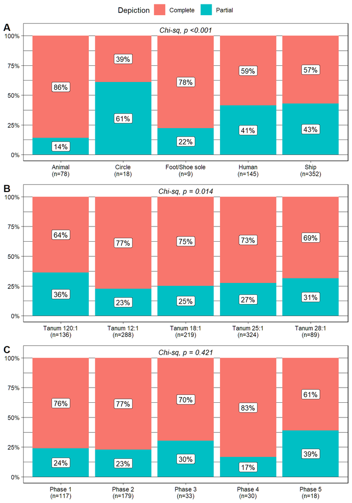

```r
# Partiality by type
df_partial_type <- AspebergetFigures %>%
  filter(Type %in% c("Animal", "Ship", "Circle", "Human", "Foot/Shoe sole")) %>%
  count(Type, Depiction) %>%
  group_by(Type) %>%
  mutate(prop = n / sum(n),
         pct_label = scales::percent(prop, accuracy = 1),
         total = sum(n)) %>%
  ungroup() %>%
  mutate(total_label = paste0(Type, "\n(n=", total, ")"))

## Plot
barp_partial_type <- df_partial_type %>%
    ggplot(aes(x = Type, y = prop, fill = Depiction)) +
        geom_col(position = "stack") +
        geom_label(aes(label = pct_label, group = Depiction),
                  position = position_stack(vjust = 0.5),
                  color = "black", fill = "white",
                  size = 3.5, show.legend = F) +
        annotate("text",
                 x = median(seq_along(unique(df_partial_type$Type))),
                 y = 1.05,
                 label = p_label_type,
                 size = 3.5,
                 fontface = "italic") +
        scale_y_continuous(labels = scales::percent_format(accuracy = 25)) +
        scale_x_discrete(labels = unique(df_partial_type$total_label)) +
        labs(x = NULL, y = NULL, fill = "Depiction") +
        theme_linedraw() +
        theme(panel.grid.major.x = element_blank())


# Partiality by panel
df_partial_panel <- AspebergetFigures %>%
    group_by(RAAnr) %>%
    filter(n() > 50) %>%
    ungroup() %>%
    count(RAAnr, Depiction) %>%
    group_by(RAAnr) %>%
    mutate(prop = n / sum(n),
           pct_label = scales::percent(prop, accuracy = 1),
           total = sum(n)) %>%
    ungroup() %>%
    mutate(total_label = paste0(RAAnr, "\n(n=", total, ")"))

## Plot
barp_partial_panel <- df_partial_panel %>%
    ggplot(aes(x = RAAnr, y = prop, fill = Depiction)) +
        geom_col(position = "stack") +
        geom_label(aes(label = pct_label, group = Depiction),
                  position = position_stack(vjust = 0.5),
                  color = "black", fill = "white",
                  size = 3.5, show.legend = F) +
        annotate("text",
                 x = median(seq_along(unique(df_partial_type$Type))),
                 y = 1.05,
                 label = p_label_raa,
                 size = 3.5,
                 fontface = "italic") +
        scale_y_continuous(labels = scales::percent_format(accuracy = 25)) +
        scale_x_discrete(labels = unique(df_partial_panel$total_label)) +
        labs(x = NULL, y = NULL, fill = "Depiction") +
        theme_linedraw() +
        theme(panel.grid.major.x = element_blank())


# Partiality by phase
df_partial_phase <- AspebergetFigures %>%
    filter(Phase %in% c(1:5)) %>%
    count(Phase, Depiction) %>%
    group_by(Phase) %>%
    mutate(prop = n / sum(n),
           pct_label = scales::percent(prop, accuracy = 1),
           total = sum(n)) %>%
    ungroup() %>%
    mutate(Phase = case_when(Phase == "1" ~ "Phase 1",
                             Phase == "2" ~ "Phase 2",
                             Phase == "3" ~ "Phase 3",
                             Phase == "4" ~ "Phase 4",
                             Phase == "5" ~ "Phase 5"),
           total_label = paste0(Phase, "\n(n=", total, ")"))

## Plot
barp_partial_phase <- df_partial_phase %>%
    ggplot(aes(x = Phase, y = prop, fill = Depiction)) +
        geom_col(position = "stack") +
        geom_label(aes(label = pct_label, group = Depiction),
                  position = position_stack(vjust = 0.5),
                  color = "black", fill = "white",
                  size = 3.5, show.legend = F) +
        annotate("text",
                 x = median(seq_along(unique(df_partial_type$Type))),
                 y = 1.05,
                 label = p_label_phase,
                 size = 3.5,
                 fontface = "italic") +
        scale_y_continuous(labels = scales::percent_format(accuracy = 25)) +
        scale_x_discrete(labels = unique(df_partial_phase$total_label)) +
        labs(x = NULL, y = NULL, fill = "Depiction") +
        theme_linedraw() +
        theme(panel.grid.major.x = element_blank())


# Combine plots
ggarrange(barp_partial_type, barp_partial_panel, barp_partial_phase,
          ncol = 1, common.legend = TRUE, legend = "top", labels = "AUTO")
```

## Morphometrics

### Outline extraction

Ship images were collected as .jpg files into `BohuslanShips.shp` using ArcGIS Pro (v3.1+), keeping the same dimensions and resolutions. The ships were manually oriented and flipped so that their prows faced to the right. Otherwise, two identical ships would be grouped into two different clusters simply because of their direction (an aspect that is not analyzed in this study). Since crews are not part of the analysis either, they were manually removed. Similarly, hulls were filled to avoid issues when extracting the outlines.

**Tip**

The extraction of outlines can take some time. The process can be skipped by loading a .rds file with `outlines <- readRDS(here("output/outlines.rds"))`

```r
# Listing images
lf_outlines <- list.files(here("data/jpg"), full.names = TRUE)

# Extract outlines from images and combine (silent)
sink(tempfile())
outlines <- Out(import_jpg(lf_outlines))
sink()

# Arrange metadata
outlines_md <- tibble(DIGARVID = names(outlines)) %>%
    left_join(BohuslanShips)

# Add metadata to outlines
outlines$fac <- outlines_md

# Save outlines
saveRDS(outlines, here("output/outlines.rds"))
```

### Standardization of outlines

Given the characteristics of the outlines analyzed, they were not normalized but only centered, scale, and oriented (sees section “Elliptical Fourier Analysis” below).

**Tip**

The process can be skipped by loading a .rds file with `outlines_standard <- readRDS(here("output/outlines_standard.rds"))`

```r
# Center, scale, and orient
outlines_standard <- outlines %>%
    coo_center() %>%
    coo_scale() %>%
    coo_slidedirection(direction = "up")

# Save standardize outlines with medatada in .rds file
saveRDS(outlines_standard, here("output/outlines_standard.rds"))
```

### Shape complexity

The complexity of a shape was calculated using the commonly used perimeter-to-area ratio. However, the perimeter-to-area ratio has an undesirable relationship with polygon size. Keeping the shape unchanged, a larger polygon will always have a smaller perimeter-to-area ratio. Therefore, the ratio was calculated after shapes were oriented and scaled using the morphometric methods mentioned above (Bonhomme et al. 2014).

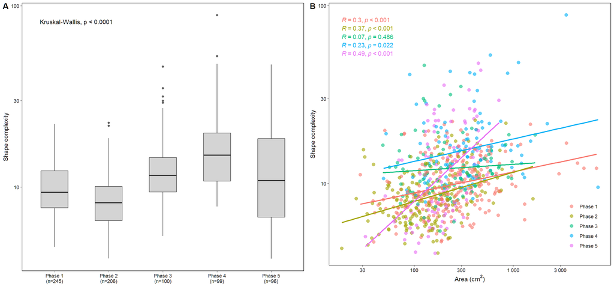

```r
# Calculate shape metrics.
outlines_metrics <- outlines_standard %>%
    Momocs::mutate(PerimToArea = coo_perim(.) / coo_area(.))

# Complexity by phase
bp_complexity <- outlines_metrics$fac %>%
    group_by(Phase) %>%
    mutate(total = n(), PhaseN = paste0(Phase, "\n(n=", total, ")")) %>%
    ungroup() %>%
    ggplot(aes(x = PhaseN, y = PerimToArea)) +
    geom_boxplot(alpha = 0.5,
                 outlier.alpha = 0.75,
                 fill = "darkgrey",
                 width = 0.5) +
    stat_kruskal_test(label.y = 1.9, label.x = 1) +
    scale_y_log10(labels = label_number()) +
    theme_linedraw() +
    theme(panel.grid = element_blank()) +
    labs(x = NULL, y = "Shape complexity")


# Complexity vs size
sctp_complexity_size <- outlines_metrics$fac %>%
    # convert area to cm2
    mutate(Area = Area * 10000)  %>%
    ggplot(aes(x = Area, y = PerimToArea, color = Phase)) +
    geom_point(alpha = 0.6, size = 2.5) +
    geom_smooth(method = "lm", se = F, show.legend = FALSE) +
    scale_x_log10(labels = label_number()) +
    scale_y_log10(labels = label_number()) +
    stat_cor(p.accuracy = 0.001, r.accuracy = 0.01, show.legend = FALSE) +
    theme_linedraw() +
    theme(panel.grid = element_blank(),
          legend.title = element_blank(),
          legend.position = "inside",
          legend.position.inside = c(0.9, 0.15)) +
    labs(x = expression(paste("Area ", "(", cm^{2}, ")")),
         y = "Shape complexity")

# Combine plots
ggarrange(bp_complexity, sctp_complexity_size, nrow = 1, labels = "AUTO")
```

### Elliptical Fourier Analysis

The number of harmonics required for EFA was automatically calculated using [harmonic power calibration](https://momx.github.io/Momocs/reference/calibrate_harmonicpower.html). EFA coefficients were *not* normalized. Commonly, outlines are [normalized](https://momx.github.io/Momocs/reference/efourier.html) by removing the first harmonic (Bonhomme et al. 2014). However, if the shapes are prone to poor alignment among the first ellipses, this will result in poorly (or even not at all) “homologous” coefficients. Shapes particularly prone to this are either (at least roughly) circular and/or strongly bilaterally symmetric, which is the case for the ships analyzed here. Consequently, the figures were manually oriented, and the first harmonic (not used for this purpose) was eliminated[^1].

**Tip**

The calculation of harmonics and EFA can take some time. The process can be skipped by loading a .rds file with `efa_outlines <- readRDS(here("output/efa_outlines.rds"))`

```r
# Estimate harmonics
harmonics_outlines <- outlines_standard %>%
    calibrate_harmonicpower_efourier(plot = F)

# Eliptical fourier of all ships
efa_outlines <- outlines_standard %>%
    efourier(nb.h = as.matrix(harmonics_outlines[["minh"]])[[4,1]], norm = F)

# Save efa in .rds file
saveRDS(efa_outlines, here("output/efa_outlines.rds"))

# Remove the first harmonic (first ellipse) not used for normalization
efa_outlines_harm2 <- efa_outlines %>% rm_harm(1)
```

### Allometry

Allometry examines the relationship between shape and size, with particular emphasis on changes in proportions. This analysis is relevant because the morphological characteristics of rock art figures can vary with size. In other words, the smaller the figure, the more limited the ability to include details and complex shapes. For the allometric analysis, this study uses the multivariate regression of shape on centroid size method proposed by Klingenberg (2016).

**Warning**

`momocs` does not offer a built-in implementation of allometry. Therefore, the coefficients obtained in Momocs were analyzed with the `geomorph` package. This is an experimental approach and it should be taken carefully. Nonetheless, with or without allometric correction, the results are essentially the same.

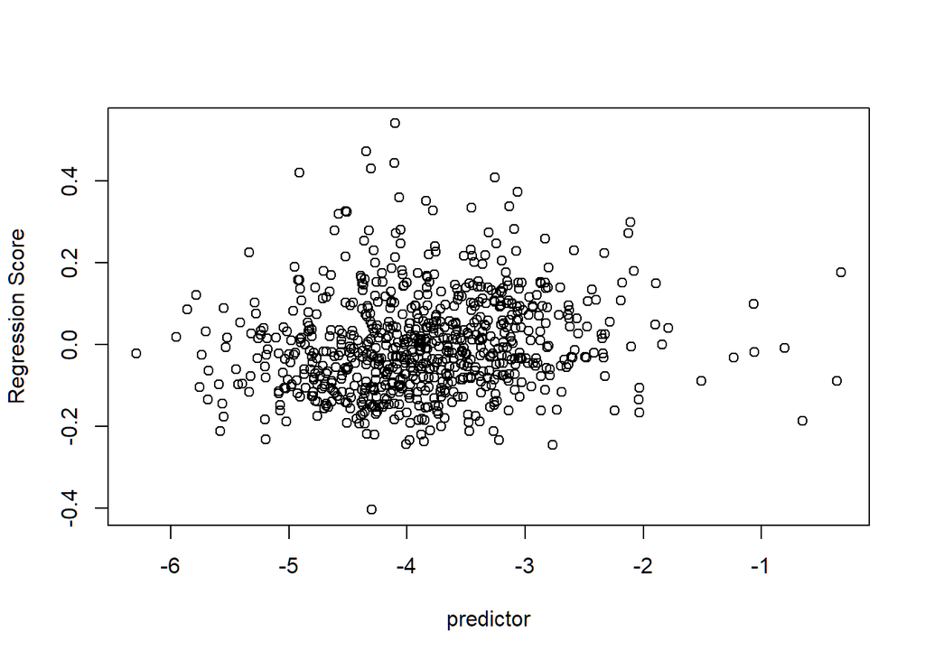

```r
# Using Momocs for outline analysis
shape_data <- efa_outlines_harm2$coe  # shape coefficients
size_data <- data.frame(size = outlines$Area)

# Use geomorph for allometry modeling
proc_model <- procD.lm(shape_data ~ size, data = size_data)
plotAllometry(proc_model, size = size_data$size, method = "RegScore")
```

```r
# Size correction
efa_allometry <- efa_outlines_harm2
efa_allometry$coe <- proc_model$residuals
```

## Multivariate analysis

### Principal component analysis and Manova

PCA and Manova are used to analyze statistical differences between ships of different phases.

**Tip**

The code can be easily modified to analyze other features commented in the study, such as differences between geographical areas (`Kommun`), crewed and uncrewed ships (`Crew`), or ships with different types of hulls (`Hull`).

```r
## PCA
pca_outlines <- PCA(efa_allometry)

# MANOVA
manova_phases <- MANOVA(pca_outlines, ~Phase)
pwmanova_phase <- MANOVA_PW(pca_outlines, ~Phase)
```

```
$stars.tab
        Phase 1 Phase 2 Phase 3 Phase 4 Phase 5
Phase 1         ***     ***     ***     ***
Phase 2                 ***     ***     ***
Phase 3                         ***     ***
Phase 4                                 ***

$summary (see also $manovas)
                  Df Pillai approx F num Df den Df    Pr(>F)
Phase 1 - Phase 2  1 0.2772    6.519     25    425 2.966e-18
Phase 1 - Phase 3  1 0.3951    8.335     25    319 9.453e-23
Phase 1 - Phase 4  1 0.5972   18.860     25    318 1.059e-48
Phase 1 - Phase 5  1 0.4790   11.582     25    315 1.235e-31
Phase 2 - Phase 3  1 0.5149   11.888     25    280 3.143e-31
Phase 2 - Phase 4  1 0.7086   27.144     25    279 2.113e-60
Phase 2 - Phase 5  1 0.5466   13.307     25    276 2.025e-34
Phase 3 - Phase 4  1 0.4441    5.528     25    173 2.817e-12
Phase 3 - Phase 5  1 0.6172   10.963     25    170 3.834e-24
Phase 4 - Phase 5  1 0.6255   11.292     25    169 1.054e-24
```

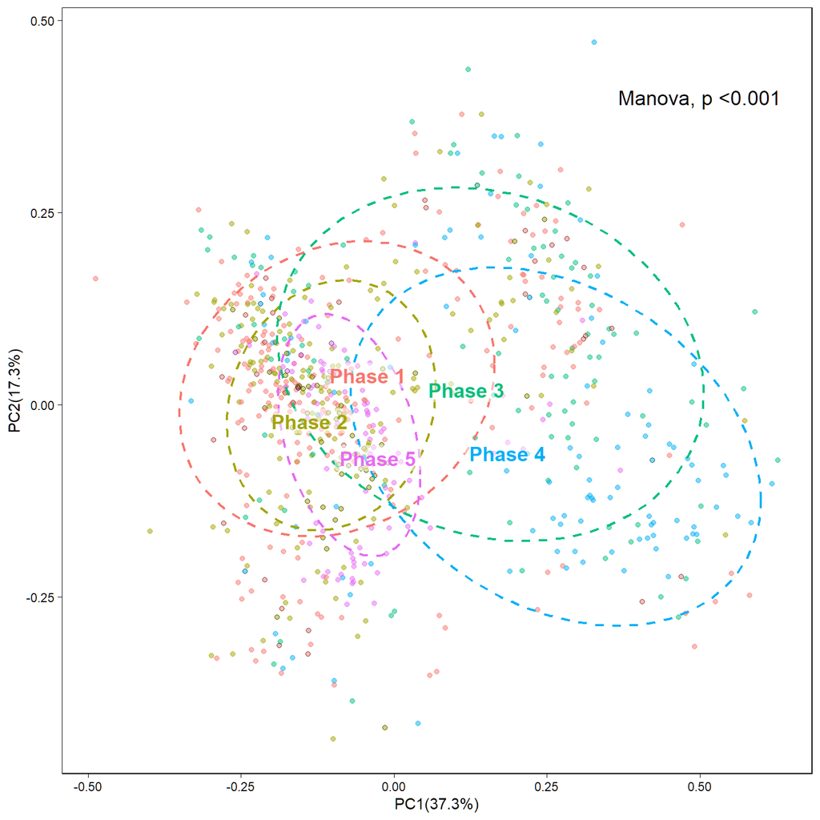

```r
## Percentage of variance of PC1 and PC2
percent_variance_outlines <- summary(pca_outlines)$importance[2,1:2]
percent_variance_outlines <- percent_variance_outlines * 100

# Labs with percetange of variance
labs_pca_outlines <- c(glue("PC1({round(percent_variance_outlines[1], 1)}%)"),
                       glue("PC2({round(percent_variance_outlines[2], 1)}%)"))

# Labels for plotting phase
phase_centers <- pca_outlines$x %>%
    as.data.frame() %>%
    rownames_to_column("DIGARVID") %>%
    left_join(outlines_md) %>%
    group_by(Phase) %>%
    summarise(PC1_mean = mean(PC1),
              PC2_mean = mean(PC2))

# PCA plot of phases
pca_plot_phases <- pca_outlines$x %>%
    as.data.frame() %>%
    rownames_to_column("DIGARVID") %>%
    left_join(outlines_md) %>%
    ggplot(aes(x = PC1, y = PC2, color = Phase)) +
    geom_point(alpha = 0.5) +
    # highlight Aspberget cases
    geom_point(data = .%>% filter(Scale == "Aspeberget"),
               shape = 1, color = "black", alpha = 0.5) +
    stat_ellipse(level = 0.68, linetype = 2, linewidth = 0.75) +
    geom_label_repel(data = phase_centers,
                    aes(x = PC1_mean, y = PC2_mean, label = Phase, color = Phase),
                    fontface = "bold", size = 5, label.size = NA, fill = scales::alpha("white", 0.5)) +
    # add manova p-value
    annotate("text", x = 0.5, y = 0.4,
             label = glue("Manova, p {scales::pvalue(manova_phases$stats['fac', 'Pr(>F)'])}"), size = 5) +
    labs(x = labs_pca_outlines[1], y = labs_pca_outlines[2]) +
    theme_linedraw() +
    theme(panel.grid = element_blank(),
          legend.position = "none")

plot(pca_plot_phases)
```

### Principal component analysis by municipality (*kommun*)

The analysis presented above has a clear limitation. For the purposes of this study, the analysis of morphological differences between figures from different phases (which are usually evident to the naked eye) is of secondary importance. The goal is to detect morphological differences within each phase and evaluate whether this variation correlates with different *areas* of Bohuslän where communities of practice with different artistic styles may have existed. To this end, the following analysis distinguishes between phases and groups observations by municipality.

**Warning**

Municipalities are used only as an artificial boundary to visualize possible stylistic differences between distant areas of Bohuslän. Obviously, these geographical boundaries most likely did not exist during the Bronze Age.

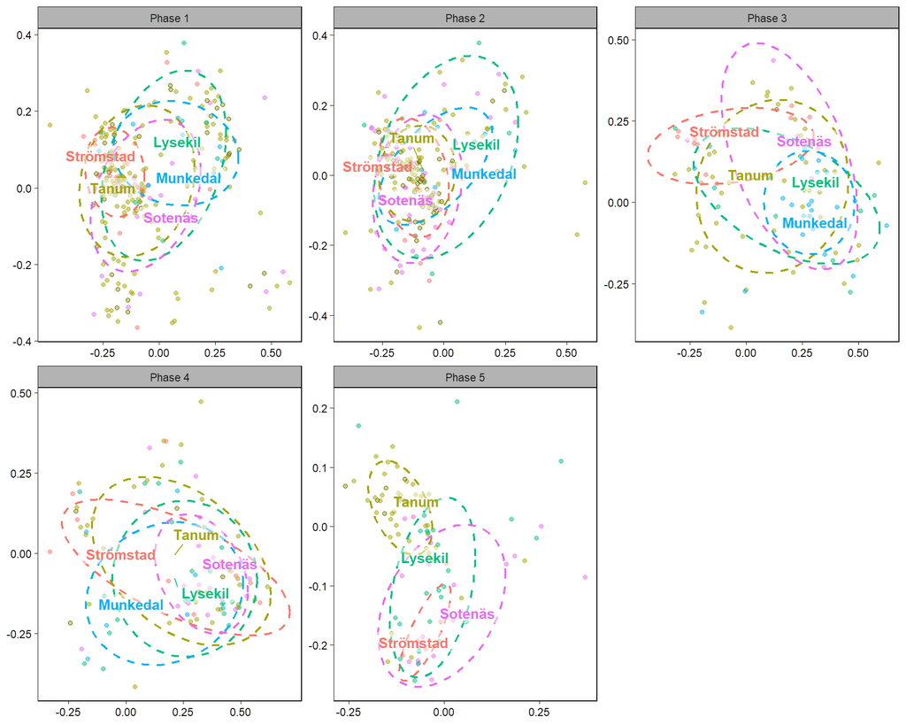

```r
# Median of PC1 and PC2 per Kommun and Phase to make labels
kommun_centers_phase <- pca_outlines$x %>%
    as.data.frame() %>%
    rownames_to_column("DIGARVID") %>%
    left_join(outlines_md) %>%
    group_by(Phase, Kommun) %>%
    summarise(PC1_mean = mean(PC1),
              PC2_mean = mean(PC2),
              .groups = "drop")

# PCA plot faceted by Phase
pca_plot_kommun_phase <- pca_outlines$x %>%
    as.data.frame() %>%
    rownames_to_column("DIGARVID") %>%
    left_join(outlines_md) %>%
    mutate(Kommun = fct_relevel(Kommun,
                               "Strömstad",
                               "Tanum",
                               "Lysekil",
                               "Munkedal",
                               "Sotenäs")) %>%
    ggplot(aes(x = PC1, y = PC2, color = Kommun)) +
    geom_point(alpha = 0.5) +
    # highlight Aspeberget cases
    geom_point(data = . %>% filter(Scale == "Aspeberget"),
               shape = 1, color = "black", alpha = 0.5) +
    stat_ellipse(level = 0.68, linetype = 2, linewidth = 0.75, show.legend = F) +
    # Add Kommun labels per Phase
    geom_label_repel(data = kommun_centers_phase,
              aes(x = PC1_mean, y = PC2_mean, label = Kommun, color = Kommun),
              inherit.aes = FALSE, fontface = "bold", size = 4, label.size = NA, fill = scales::alpha("white", 0.5)) +
    scale_x_continuous(breaks = seq(-0.25, 0.50, 0.25)) +
    labs(x = NULL, y = NULL, color = NULL) +
    theme_light() +
    theme(panel.grid = element_blank(),
          legend.position = "none",
          axis.ticks = element_line(color = "black"),
          axis.text.x = element_text(color = "black"),
          axis.text.y = element_text(color = "black"),
          panel.border = element_rect(color = "black"),
          strip.text = element_text(color = "gray10"),
          strip.background = element_rect(color = "black")) +
    facet_wrap(vars(Phase), scales = "free")

pca_plot_kommun_phase
```

## Median shapes

A [mean shape](https://momx.github.io/Momocs/reference/MSHAPES.html?q=mean#null) is the average configuration of a set of outlines after alignment via Elliptical Fourier Analysis. It is a mathematical abstraction that does not necessarily correspond to any single figure, but it serves as a baseline for comparison. In this study, it is used to calculate the *median* shape of ship figures by phase.

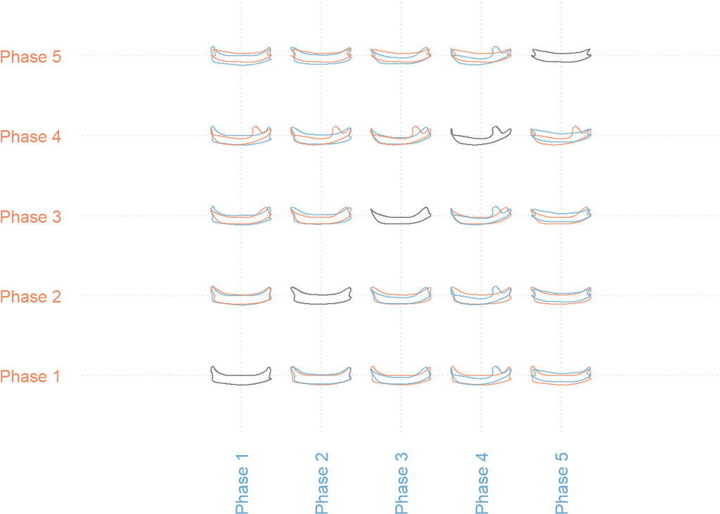

```r
# Median shapes by phase (1 to 5)
medianshapes <- MSHAPES(efa_outlines, ~Phase, FUN = median, nb.pts = 500)

# Plot
plot_MSHAPES(medianshapes)
```

## Disparity analysis

This sections analyzes shaoe disparty between phases in ship outlines. According to its author (Guillerme 2018), the dispRity package is:

> *A modular package for measuring disparity (multidimensional space occupancy). Disparity can be calculated from any matrix defining a multidimensional space. The package provides a set of implemented metrics to measure properties of the space and allows users to provide and test their own metrics. The package also provides functions for looking at disparity in a serial way (e.g. disparity through time) or per groups as well as visualising the results. Finally, this package provides several statistical tests for disparity analysis.*

Disparity is measured as the sum of variances of the fourier coefficients.

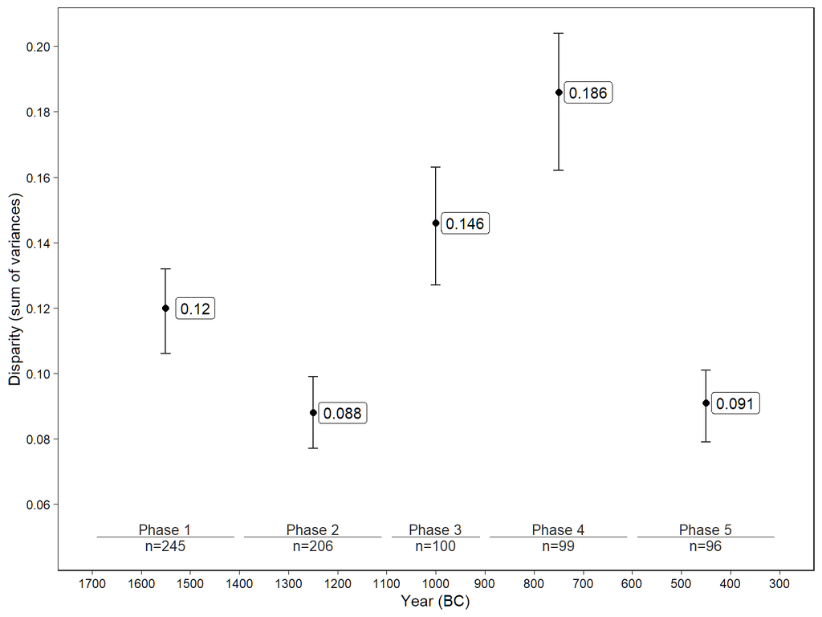

```r
# Find indices for each phase in the dataset
phases_index <- pca_outlines$fac %>%
    mutate(row = row_number()) %>%
    split(.$Phase) %>%
    map(~ .x$row)

# Disparity index on pca componentes
disparity_phases <- dispRity(boot.matrix(custom.subsets(pca_outlines$x,
                                                        phases_index),
                                 bootstraps = 1000),
                            metric = c(sum, variances))

# Segments to show the length of phases
segments <- tibble(x = c(1690, 1390, 1090, 890, 590),
                   y = c(0.05, 0.05, 0.05, 0.05, 0.05),
                   xend = c(1410, 1110, 910, 610, 310),
                   yend = c(0.05, 0.05, 0.05, 0.05, 0.05),
                   label = c("Phase 1", "Phase 2", "Phase 3", "Phase 4", "Phase 5"),
                   n = c(paste0("n", "=", summary.dispRity(disparity_phases)[1,2]),
                         paste0("n", "=", summary.dispRity(disparity_phases)[2,2]),
                         paste0("n", "=", summary.dispRity(disparity_phases)[3,2]),
                         paste0("n", "=", summary.dispRity(disparity_phases)[4,2]),
                         paste0("n", "=", summary.dispRity(disparity_phases)[5,2])))

# Plot
summary.dispRity(disparity_phases) %>%
    mutate(Year = case_when(subsets == "Phase 1" ~ 1550,
                            subsets == "Phase 2" ~ 1250,
                            subsets == "Phase 3" ~ 1000,
                            subsets == "Phase 4" ~ 750,
                            subsets == "Phase 5" ~ 450)) %>%
    ggplot(aes(x = Year, y = obs, label = obs)) +
        geom_errorbar(aes(ymin = `2.5%`, ymax = `97.5%`),
                      width = 20,
                      color = "grey15") +
        geom_point(size = 2) +
        geom_label(nudge_x = 60) +
        scale_x_reverse(limits = c(1700, 300),
                           breaks = seq(300, 1700, 100)) +
        scale_y_continuous(breaks = seq(0.06, 0.24, 0.02)) +
        geom_segment(data = segments,
                     mapping = aes(x = x, y = y, xend = xend, yend = yend),
                     linewidth = 0.3,
                     inherit.aes = F, color = "grey15") +
        geom_text(data = segments, aes(x = (x + xend) / 2, y = y, label = label),
                  nudge_y = 0.0025, size = 3.5, color = "grey15") +
        geom_text(data = segments, aes(x = (x + xend) / 2, y = y, label = n),
                  nudge_y = -0.0025, size = 3.5, color = "grey15") +
        labs(x = "Year (BC)", y = "Disparity (sum of variances)") +
        theme_linedraw() +
        theme(panel.grid = element_blank())
```

## References

Bonhomme, V., Picq, S., Gaucherel, C., and Claude, J. 2014. “Momocs: Outline Analysis Using R.” Journal of Statistical Software 56 (13): 1–24. https://doi.org/10.18637/jss.v056.i13.

Giardina, C. R., and Kuhl, F. P. 1977. “Accuracy of Curve Approximation by Harmonically Related Vectors with Elliptical Loci.” Computer Graphics and Image Processing 6 (3): 277–85. https://doi.org/10.1016/S0146-664X(77)80029-4.

Guillerme, T. 2018. “dispRity: A Modular R Package for Measuring Disparity.” Methods in Ecology and Evolution 9 (7): 1755–63. https://doi.org/10.1111/2041-210X.13022.

Klingenberg, C. P., 2016. “Size, shape, and form: concepts of allometry in geometric morphometrics”. *Dev Genes Evol.* 226 (3): 113-37. https://doi.org/10.1007/s00427-016-0539-2.

## Footnotes

[^1]: Note that the first harmonic captures the largest axial dimension of the ship, namely its length. Consequently, shape and length are not entirely independent. Two ships with a similar design may appear morphologically different simply because their hull lengths differ. Removing the first harmonic may help reduce this size-related bias and mitigates the emergence of gradient-like representations (the horseshoe effect) in principal component analysis (PCA).